# znacajke

0036558540 Ivan Dražetić

2026-01-18

# Istraživačko pitanje: Možemo li pomoću dostupnih značajki pouzdano razlikovati pobjednike od ostalih?

#### U ovom dijelu analiziramo postoje li statistički značajne razlike između filmova koji su osvojili Oscara (“Winner”) i onih koji su bili samo nominirani (“Nominee”). Analizu provodimo na temelju dostupnih značajki: IMDb ocjene, broja glasova, trajanja filma i žanra.

```r
oscars <- read.csv2("oscars_dataset.csv")
# glimpse(oscars)
```

#### Priprema i čišćenje podataka

Prije analize potrebno je urediti tipove podataka, ukloniti zareze iz numeričkih varijabli te kreirati binarnu varijablu za ishod (Pobjednik = 1, Nominirani = 0). Također, grupirat ćemo rjeđe žanrove u kategoriju “Other” radi stabilnije analize.

```r
oscars <- oscars %>%
  mutate(
    IMDB.Rating = as.numeric(IMDB.Rating),
    IMDB.Votes = as.numeric(gsub(",", "", IMDB.Votes)),
    Movie.Time = as.numeric(Movie.Time),
    Year = as.numeric(Year.of.Release),
    IsWinner = ifelse(Award == "Winner", 1, 0),
    GenreGroup = ifelse(Main.Genre %in% c("Action", "Adventure", "Biography", "Comedy", "Crime", "Drama"),
                        Main.Genre, "Other")
  ) %>%
  filter(complete.cases(IMDB.Rating, IMDB.Votes, Movie.Time, Year, GenreGroup))

# Pretvorba u faktore
oscars$GenreGroup <- factor(oscars$GenreGroup)
oscars$Award <- factor(oscars$Award, levels = c("Nominee", "Winner"))
```

### 1. Deskriptivna analiza: IMDb ocjene

Prvo ćemo ispitati razlikuju li se pobjednici od nominiranih prema IMDb ocjeni. Koristit ćemo robusne mjere (medijan i IQR) uz standardne mjere, kako bismo dobili bolji uvid u distribuciju.

```r
stats_rating <- oscars %>%
  group_by(Award) %>%
  summarise(
    Mean = mean(IMDB.Rating),
    Median = median(IMDB.Rating),
    SD = sd(IMDB.Rating),
    IQR = IQR(IMDB.Rating),
    Count = n()
  )

print(stats_rating)
```

```
## # A tibble: 2 × 6
##   Award    Mean Median    SD   IQR Count
##   <fct>   <dbl>  <dbl> <dbl> <dbl> <int>
## 1 Nominee  7.53    7.6 0.534 0.7     477
## 2 Winner   7.78    7.9 0.637 0.700    94
```

#### Vizualizacija distribucije ocjena

[figure not shown]

```r
ggplot(oscars, aes(x = Award, y = IMDB.Rating, fill = Award)) +
  geom_boxplot() +
  labs(
    x = "Ishod",
    y = "IMDb ocjena",
    title = "Distribucija IMDb ocjena: Pobjednici vs. Nominirani"
  ) +
  theme_minimal()
```

S boxplota i izračunatih mjera vidljivo je da pobjednici imaju blago viši medijan ocjena. Prije nego što statistički testiramo tu razliku t-testom, moramo provjeriti pretpostavke: normalnost podataka i homogenost varijanci.

#### Provjera normalnosti (QQ-plot)

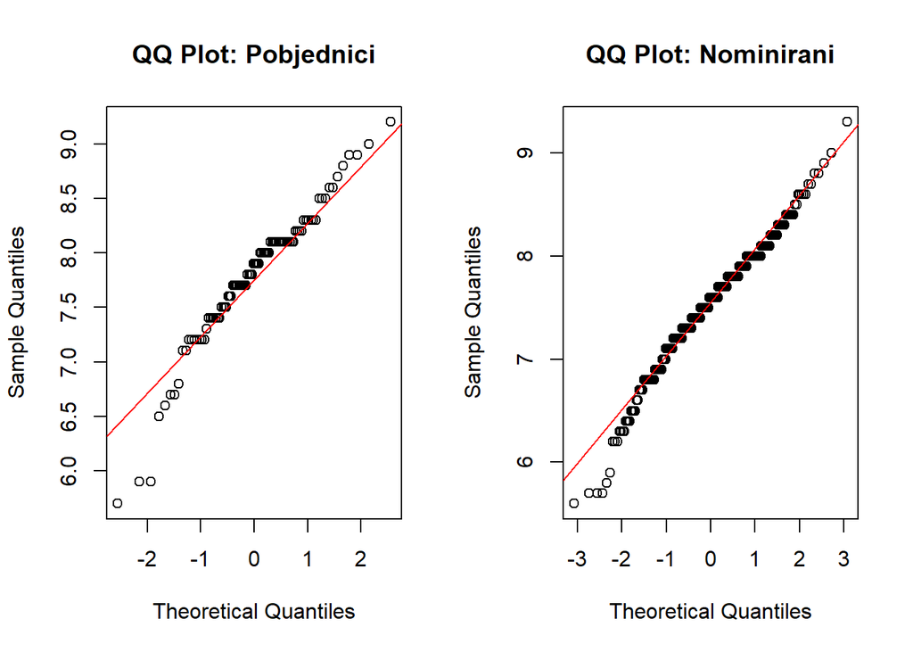

```r
par(mfrow=c(1,2))
qqnorm(oscars$IMDB.Rating[oscars$Award == "Winner"], main = "QQ Plot: Pobjednici")
qqline(oscars$IMDB.Rating[oscars$Award == "Winner"], col = "red")

qqnorm(oscars$IMDB.Rating[oscars$Award == "Nominee"], main = "QQ Plot: Nominirani")
qqline(oscars$IMDB.Rating[oscars$Award == "Nominee"], col = "red")
```

```r
par(mfrow=c(1,1))
```

Podaci prate liniju normalne distribucije dovoljno dobro za provođenje parametrijskih testova. Sljedeći korak je provjera jednakosti varijanci F-testom.

#### Test jednakosti varijanci (F-test)

```r
var.test(IMDB.Rating ~ Award, data = oscars)
```

```
##
##  F test to compare two variances
##
## data:  IMDB.Rating by Award
## F = 0.7021, num df = 476, denom df = 93, p-value = 0.01999
## alternative hypothesis: true ratio of variances is not equal to 1
## 95 percent confidence interval:
##  0.5033749 0.9466244
## sample estimates:
## ratio of variances
##          0.7020958
```

#### T-test za nezavisne uzorke

```r
t.test(IMDB.Rating ~ Award, data = oscars, var.equal = TRUE)
```

```
##
##  Two Sample t-test
##
## data:  IMDB.Rating by Award
## t = -4.0212, df = 569, p-value = 6.572e-05
## alternative hypothesis: true difference in means between group Nominee and group Winner is not equal to 0
## 95 percent confidence interval:
##  -0.3730752 -0.1282184
## sample estimates:
## mean in group Nominee  mean in group Winner
##              7.529140              7.779787
```

Rezultati t-testa (p < 0.05) pokazuju da postoji statistički značajna razlika u srednjim vrijednostima ocjena. Pobjednici u prosjeku imaju više ocjene od nominiranih.

### 2. Analiza kategorijskih varijabli: Žanr

Imaju li određeni žanrovi veću vjerojatnost pobjede?

```r
genre_table <- table(oscars$GenreGroup, oscars$Award)
addmargins(genre_table)
```

```
##
##             Nominee Winner Sum
##   Action         36      3  39
##   Adventure      36      9  45
##   Biography      83     18 101
##   Comedy         95     13 108
##   Crime          39      9  48
##   Drama         173     42 215
##   Other          15      0  15
##   Sum           477     94 571
```

```r
chisq.test(genre_table)
```

```
##
##  Pearson's Chi-squared test
##
## data:  genre_table
## X-squared = 8.8789, df = 6, p-value = 0.1805
```

Chi-square test daje p-vrijednost veću od 0.05 (ovisno o točnom uzorku), što sugerira da žanr sam po sebi možda nije presudan faktor za razlikovanje pobjednika od nominiranih u ovom skupu podataka.

### 3. Višestruka linearna regresija

Kako bismo utvrdili možemo li pouzdano razlikovati pobjednike koristeći više značajki istovremeno (ocjena, glasovi, trajanje, godina), gradimo linearni regresijski model. Prije toga provjeravamo korelaciju među numeričkim prediktorima kako bismo izbjegli multikolinearnost.

#### Korelacijska matrica

```r
cor(oscars[, c("IMDB.Rating", "IMDB.Votes", "Movie.Time", "Year")])
```

```
##             IMDB.Rating IMDB.Votes Movie.Time      Year
## IMDB.Rating   1.0000000  0.5998699  0.2923566 0.3299097
## IMDB.Votes    0.5998699  1.0000000  0.2808458 0.4914799
## Movie.Time    0.2923566  0.2808458  1.0000000 0.2420179
## Year          0.3299097  0.4914799  0.2420179 1.0000000
```

Korelacije nisu pretjerano visoke (sve su ispod 0.7), pa možemo uključiti ove varijable u model.

#### Izgradnja modela

Koristimo linearni vjerojatnosni model gdje je zavisna varijabla IsWinner (0 ili 1). Također koristimo logaritam broja glasova (log(IMDB.Votes)) jer ta varijabla često ima asimetričnu distribuciju.

```r
model_full <- lm(IsWinner ~ IMDB.Rating + log(IMDB.Votes) + Movie.Time + Year + GenreGroup,
                 data = oscars)

summary(model_full)
```

```
##
## Call:
## lm(formula = IsWinner ~ IMDB.Rating + log(IMDB.Votes) + Movie.Time +
##     Year + GenreGroup, data = oscars)
##
## Residuals:
##      Min       1Q   Median       3Q      Max
## -0.60672 -0.20072 -0.10337  0.04679  0.99404
##
## Coefficients:
##                       Estimate Std. Error t value Pr(>|t|)
## (Intercept)         12.6572366  1.6860274   7.507 2.39e-13 ***
## IMDB.Rating         -0.1567078  0.0400400  -3.914 0.000102 ***
## log(IMDB.Votes)      0.1392421  0.0163091   8.538  < 2e-16 ***
## Movie.Time           0.0022270  0.0006057   3.677 0.000259 ***
## Year                -0.0067063  0.0008501  -7.889 1.61e-14 ***
## GenreGroupAdventure  0.1136236  0.0746787   1.521 0.128699
## GenreGroupBiography  0.1761350  0.0643035   2.739 0.006357 **
## GenreGroupComedy     0.1280326  0.0645148   1.985 0.047683 *
## GenreGroupCrime      0.1176309  0.0737643   1.595 0.111346
## GenreGroupDrama      0.1988164  0.0597204   3.329 0.000928 ***
## GenreGroupOther     -0.0391715  0.1044799  -0.375 0.707862
## ---
## Signif. codes:  0 '***' 0.001 '**' 0.01 '*' 0.05 '.' 0.1 ' ' 1
##
## Residual standard error: 0.3383 on 560 degrees of freedom
## Multiple R-squared:  0.1839, Adjusted R-squared:  0.1693
## F-statistic: 12.62 on 10 and 560 DF,  p-value: < 2.2e-16
```

### 4. Dijagnostika modela

Na kraju, provjeravamo reziduale modela kako bismo vidjeli jesu li pretpostavke linearne regresije narušene.

#### Histogram reziduala

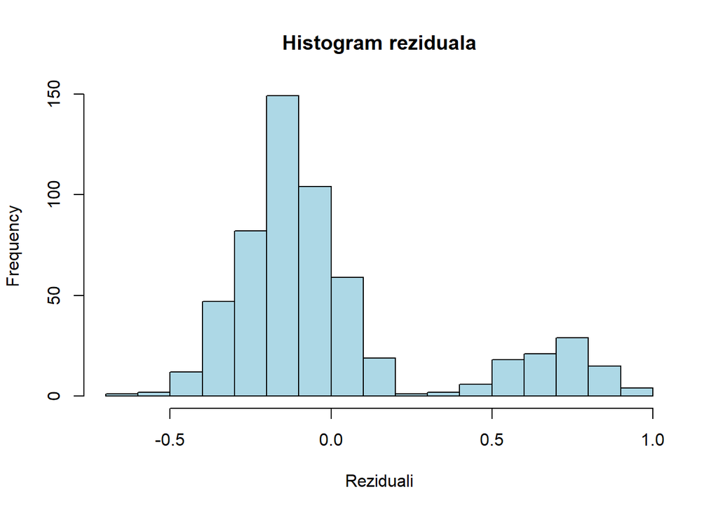

```r
hist(model_full$residuals,
     main = "Histogram reziduala",
     xlab = "Reziduali",
     col = "lightblue",
     breaks = 20)
```

#### QQ-plot reziduala i Reziduali vs. Predviđene vrijednosti

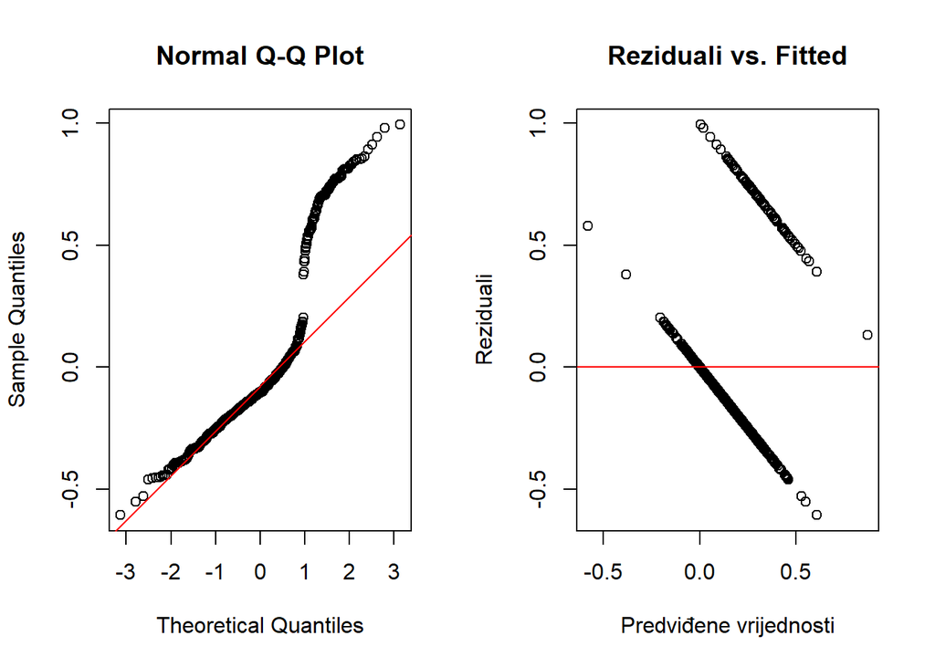

```r
par(mfrow=c(1,2))
qqnorm(model_full$residuals)
qqline(model_full$residuals, col = "red")

plot(model_full$fitted.values, model_full$residuals,
     main = "Reziduali vs. Fitted",
     xlab = "Predviđene vrijednosti",
     ylab = "Reziduali")
abline(h = 0, col = "red")
```

```r
par(mfrow=c(1,1))
```

Dijagnostički grafovi pokazuju određena odstupanja. Histogram nije savršeno zvonolik, a QQ-plot pokazuje otklone na repovima. To je očekivano s obzirom da modeliramo binarni ishod (0/1) linearnom regresijom.

### Zaključak

Iako smo pronašli statistički značajne razlike (pobjednici su u prosjeku bolje ocijenjeni i duži), ne možemo pouzdano razlikovati pobjednike od ostalih samo na temelju ovih značajki. Nizak koeficijent determinacije (R^2) sugerira da postoje drugi, ovdje neuhvaćeni faktori (npr. kvaliteta režije, marketing, narativ) koji presudno utječu na pobjedu.